# **Evaluating the Suitability of Lithic Illustrations in Morphometric Analyses**

### **Stage 5: Further analysis (MANOVA and Discriminant Analysis)**

Each individual artefact (and the collections of drawings for each artefact) was then analysed to examine whether differences in illustrator skill were observed. This was first done through a Procrustes ANOVA, providing a statistical framework for detecting any such difference. Discriminant analyses were then conducted for each artefact to test for between-group variance. The code for each artefact follows this order:

1. The Procrustes coordinates from an artefact are extracted from the dataframe.
2. A geomorph-specific data-frame is created through the `geomorph::geomorph.data.frame()` function, with the Procrustes coordinates and the class factor.
3. A Procrustes ANOVA is then performed through the `geomorph::procD.lm()` function, with the results summarised through the `base::summary()` argument.
4. A new data frame is generated to produce the discriminant analysis (through the `MASS::lda() function`).
5. The subsequent data is visualised through the `tidyverse` package.
6. This is repeated for each artefact within each artefact class.

```r
elongated1 <- gpa_elongated$coords[, , 1:18]
df_elongated1 <- geomorph.data.frame(shape = elongated1, class = shape_data_elongated$Class[1:18], artefact = shape_data_elongated$Artefact[1:18])
E1 <- procD.lm(shape ~ class, data = df_elongated1, print.progress = FALSE)
summary(E1)
```

```
##
## Analysis of Variance, using Residual Randomization
## Permutation procedure: Randomization of null model residuals
## Number of permutations: 1000
## Estimation method: Ordinary Least Squares
## Sums of Squares and Cross-products: Type I
## Effect sizes (Z) based on F distributions
##
##           Df        SS         MS     Rsq      F       Z Pr(>F)
## class      3 0.0016387 0.00054623 0.17824 1.0122 0.18333  0.398
## Residuals 14 0.0075548 0.00053963 0.82176
## Total     17 0.0091935
##
## Call: procD.lm(f1 = shape ~ class, data = df_elongated1, print.progress = FALSE)
```

```r
elongated1pcs <- as.data.frame(pca_elongated$x[1:18, 1:10])
elongated1class <- shape_data_elongated$Class[1:18]
elongated1pcs <- cbind(elongated1pcs, elongated1class)
elongated1pcs <- rename(elongated1pcs, Class = elongated1class)
elongated1lda <- lda(Class ~ ., data = elongated1pcs)
elongated1ldapredict <- predict(elongated1lda)
elongated1ldaplot <- cbind(elongated1ldapredict$x[, 1:3], elongated1pcs)
elongated1ldaplotggplot <- ggplot(elongated1ldaplot, aes(LD1, LD2)) +
  geom_point(aes(shape = Class), size = 2) +
  labs(x = "LDA 1", y = "LDA 2") +
  scale_shape_manual(values=c(17,15,3,16)) +
  theme_minimal() +
  theme(axis.text.x = element_blank(),
        axis.text.y = element_blank(),
        axis.title.x = element_text(size = 6),
        axis.title.y = element_text(size = 6),
        legend.position = "none")

elongated2 <- gpa_elongated$coords[, , 19:36]
df_elongated2 <- geomorph.data.frame(shape = elongated2, class = shape_data_elongated$Class[19:36], artefact = shape_data_elongated$Artefact[19:36])
E2 <- procD.lm(shape ~ class, data = df_elongated2, print.progress = FALSE)
summary(E2)
```

```
##
## Analysis of Variance, using Residual Randomization
## Permutation procedure: Randomization of null model residuals
## Number of permutations: 1000
## Estimation method: Ordinary Least Squares
## Sums of Squares and Cross-products: Type I
## Effect sizes (Z) based on F distributions
##
##           Df        SS         MS     Rsq      F       Z Pr(>F)
## class      3 0.0007434 0.00024780 0.08883 0.4549 -1.8498  0.976
## Residuals 14 0.0076257 0.00054469 0.91117
## Total     17 0.0083691
##
## Call: procD.lm(f1 = shape ~ class, data = df_elongated2, print.progress = FALSE)
```

```r
elongated2pcs <- as.data.frame(pca_elongated$x[19:36, 1:10])
elongated2class <- shape_data_elongated$Class[19:36]
elongated2pcs <- cbind(elongated2pcs, elongated2class)
elongated2pcs <- rename(elongated2pcs, Class = elongated2class)
elongated2lda <- lda(Class ~ ., elongated2pcs)
elongated2ldapredict <- predict(elongated2lda)
elongated2ldaplot <- cbind(elongated2ldapredict$x[, 1:3], elongated2pcs)
elongated2ldaplotggplot <- ggplot(elongated2ldaplot, aes(LD1, LD2)) +
  geom_point(aes(shape = Class), size = 2) +
  labs(x = "LDA 1", y = "LDA 2") +
  scale_shape_manual(values=c(17,15,3,16)) +
  theme_minimal() +
  theme(axis.text.x = element_blank(),
        axis.text.y = element_blank(),
        legend.position = "none",
        axis.title.y = element_text(size = 6),
        axis.title.x = element_text(size = 6))

elongated3 <- gpa_elongated$coords[, , 37:54]
df_elongated3 <- geomorph.data.frame(shape = elongated3, class = shape_data_elongated$Class[37:54], artefact = shape_data_elongated$Artefact[37:54])
E3 <- procD.lm(shape ~ class, data = df_elongated3, print.progress = FALSE)
summary(E3)
```

```
##
## Analysis of Variance, using Residual Randomization
## Permutation procedure: Randomization of null model residuals
## Number of permutations: 1000
## Estimation method: Ordinary Least Squares
## Sums of Squares and Cross-products: Type I
## Effect sizes (Z) based on F distributions
##
##           Df        SS         MS     Rsq      F        Z Pr(>F)
## class      3 0.0007131 0.00023771 0.14157 0.7696 -0.28451   0.57
## Residuals 14 0.0043243 0.00030888 0.85843
## Total     17 0.0050375
##
## Call: procD.lm(f1 = shape ~ class, data = df_elongated3, print.progress = FALSE)
```

```r
elongated3pcs <- as.data.frame(pca_elongated$x[37:54, 1:10])
elongated3class <- shape_data_elongated$Class[37:54]
elongated3pcs <- cbind(elongated3pcs, elongated3class)
elongated3pcs <- rename(elongated3pcs, Class = elongated3class)
elongated3lda <- lda(Class ~ ., elongated3pcs)
elongated3ldapredict <- predict(elongated3lda)
elongated3ldaplot <- cbind(elongated3ldapredict$x[, 1:3], elongated3pcs)
elongated3ldaplotggplot <- ggplot(elongated3ldaplot, aes(LD1, LD2)) +
  geom_point(aes(shape = Class), size = 2) +
  labs(x = "LDA 1", y = "LDA 2") +
  scale_shape_manual(values=c(17,15,3,16)) +
  theme_minimal() +
  theme(axis.text.x = element_blank(),
        axis.text.y = element_blank(),
        legend.position = "none",
        axis.title.y = element_text(size = 6),
        axis.title.x = element_text(size = 6))

elongated4 <- gpa_elongated$coords[, , 55:72]
df_elongated4 <- geomorph.data.frame(shape = elongated4, class = shape_data_elongated$Class[55:72], artefact = shape_data_elongated$Artefact[55:72])
E4 <- procD.lm(shape ~ class, data = df_elongated4, print.progress = FALSE)
summary(E4)
```

```
##
## Analysis of Variance, using Residual Randomization
## Permutation procedure: Randomization of null model residuals
## Number of permutations: 1000
## Estimation method: Ordinary Least Squares
## Sums of Squares and Cross-products: Type I
## Effect sizes (Z) based on F distributions
##
##           Df        SS         MS     Rsq      F       Z Pr(>F)
## class      3 0.0007477 0.00024923 0.10896 0.5707 -0.7742  0.793
## Residuals 14 0.0061144 0.00043675 0.89104
## Total     17 0.0068621
##
## Call: procD.lm(f1 = shape ~ class, data = df_elongated4, print.progress = FALSE)
```

```r
elongated4pcs <- as.data.frame(pca_elongated$x[55:72, 1:10])
elongated4class <- shape_data_elongated$Class[55:72]
elongated4pcs <- cbind(elongated4pcs, elongated4class)
elongated4pcs <- rename(elongated4pcs, Class = elongated4class)
elongated4lda <- lda(Class ~ ., elongated4pcs)
elongated4ldapredict <- predict(elongated4lda)
elongated4ldaplot <- cbind(elongated4ldapredict$x[, 1:3], elongated4pcs)
elongated4ldaplotggplot <- ggplot(elongated4ldaplot, aes(LD1, LD2)) +
  geom_point(aes(shape = Class), size = 2) +
  labs(x = "LDA 1", y = "LDA 2") +
  scale_shape_manual(values=c(17,15,3,16)) +
  theme_minimal() +
  theme(axis.text.x = element_blank(),
        axis.text.y = element_blank(),
        legend.position = "none",
        axis.title.y = element_text(size = 6),
        axis.title.x = element_text(size = 6))

elongated5 <- gpa_elongated$coords[, , 73:90]
df_elongated5 <- geomorph.data.frame(shape = elongated5, class = shape_data_elongated$Class[73:90], artefact = shape_data_elongated$Artefact[73:90])
E5 <- procD.lm(shape ~ class, data = df_elongated5, print.progress = FALSE)
summary(E5)
```

```
##
## Analysis of Variance, using Residual Randomization
## Permutation procedure: Randomization of null model residuals
## Number of permutations: 1000
## Estimation method: Ordinary Least Squares
## Sums of Squares and Cross-products: Type I
## Effect sizes (Z) based on F distributions
##
##           Df        SS         MS    Rsq      F       Z Pr(>F)
## class      3 0.0005381 0.00017936 0.0878 0.4492 -1.2749  0.905
## Residuals 14 0.0055901 0.00039929 0.9122
## Total     17 0.0061282
##
## Call: procD.lm(f1 = shape ~ class, data = df_elongated5, print.progress = FALSE)
```

```r
elongated5pcs <- as.data.frame(pca_elongated$x[73:90, 1:10])
elongated5class <- shape_data_elongated$Class[73:90]
elongated5pcs <- cbind(elongated5pcs, elongated5class)
elongated5pcs <- rename(elongated5pcs, Class = elongated5class)
elongated5lda <- lda(Class ~ ., elongated5pcs)
elongated5ldapredict <- predict(elongated5lda)
elongated5ldaplot <- cbind(elongated5ldapredict$x[, 1:3], elongated5pcs)
elongated5ldaplotggplot <- ggplot(elongated5ldaplot, aes(LD1, LD2)) +
  geom_point(aes(shape = Class), size = 2) +
  labs(x = "LDA 1", y = "LDA 2") +
  scale_shape_manual(values=c(17,15,3,16)) +
  theme_minimal() +
  theme(axis.text.x = element_blank(),
        axis.text.y = element_blank(),
        legend.position = "none",
        axis.title.y = element_text(size = 6),
        axis.title.x = element_text(size = 6))

tanged1 <- gpa_tanged$coords[, , 1:18]
df_tanged1 <- geomorph.data.frame(shape = tanged1, class = shape_data_tanged$Class[1:18], artefact = shape_data_tanged$Artefact[1:18])
T1 <- procD.lm(shape ~ class, data = df_tanged1, print.progress = FALSE)
summary(T1)
```

```
##
## Analysis of Variance, using Residual Randomization
## Permutation procedure: Randomization of null model residuals
## Number of permutations: 1000
## Estimation method: Ordinary Least Squares
## Sums of Squares and Cross-products: Type I
## Effect sizes (Z) based on F distributions
##
##           Df        SS         MS    Rsq      F        Z Pr(>F)
## class      3 0.0006374 0.00021247 0.1445 0.7882 -0.41375  0.659
## Residuals 14 0.0037737 0.00026955 0.8555
## Total     17 0.0044111
##
## Call: procD.lm(f1 = shape ~ class, data = df_tanged1, print.progress = FALSE)
```

```r
tanged1pcs <- as.data.frame(pca_tanged$x[1:18, 1:10])
tanged1class <- shape_data_tanged$Class[1:18]
tanged1pcs <- cbind(tanged1pcs, tanged1class)
tanged1pcs <- rename(tanged1pcs, Class = tanged1class)
tanged1lda <- lda(Class ~ ., tanged1pcs)
tanged1ldapredict <- predict(tanged1lda)
tanged1ldaplot <- cbind(tanged1ldapredict$x[, 1:3], tanged1pcs)
tanged1ldaplotggplot <- ggplot(tanged1ldaplot, aes(LD1, LD2)) +
  geom_point(aes(shape = Class), size = 2) +
  labs(x = "LDA 1", y = "LDA 2") +
  scale_shape_manual(values=c(17,15,3,16)) +
  theme_minimal() +
  theme(axis.text.x = element_blank(),
        axis.text.y = element_blank(),
        legend.position = "none",
        axis.title.y = element_text(size = 6),
        axis.title.x = element_text(size = 6))

tanged2 <- gpa_tanged$coords[, , 19:36]
df_tanged2 <- geomorph.data.frame(shape = tanged2, class = shape_data_tanged$Class[19:36], artefact = shape_data_tanged$Artefact[19:36])
T2 <- procD.lm(shape ~ class, data = df_tanged2, print.progress = FALSE)
summary(T2)
```

```
##
## Analysis of Variance, using Residual Randomization
## Permutation procedure: Randomization of null model residuals
## Number of permutations: 1000
## Estimation method: Ordinary Least Squares
## Sums of Squares and Cross-products: Type I
## Effect sizes (Z) based on F distributions
##
##           Df        SS         MS     Rsq      F       Z Pr(>F)
## class      3 0.0005912 0.00019707 0.17446 0.9862 0.12861  0.418
## Residuals 14 0.0027976 0.00019983 0.82554
## Total     17 0.0033888
##
## Call: procD.lm(f1 = shape ~ class, data = df_tanged2, print.progress = FALSE)
```

```r
tanged2pcs <- as.data.frame(pca_tanged$x[19:36, 1:10])
tanged2class <- shape_data_tanged$Class[19:36]
tanged2pcs <- cbind(tanged2pcs, tanged2class)
tanged2pcs <- rename(tanged2pcs, Class = tanged2class)
tanged2lda <- lda(Class ~ ., tanged2pcs)
tanged2ldapredict <- predict(tanged2lda)
tanged2ldaplot <- cbind(tanged2ldapredict$x[, 1:3], tanged2pcs)
tanged2ldaplotggplot <- ggplot(tanged2ldaplot, aes(LD1, LD2)) +
  geom_point(aes(shape = Class), size = 2) +
  labs(x = "LDA 1", y = "LDA 2") +
  scale_shape_manual(values=c(17,15,3,16)) +
  theme_minimal() +
  theme(axis.text.x = element_blank(),
        axis.text.y = element_blank(),
        legend.position = "none",
        axis.title.y = element_text(size = 6),
        axis.title.x = element_text(size = 6))

tanged3 <- gpa_tanged$coords[, , 37:54]
df_tanged3 <- geomorph.data.frame(shape = tanged3, class = shape_data_tanged$Class[37:54], artefact = shape_data_tanged$Artefact[37:54])
T3 <- procD.lm(shape ~ class, data = df_tanged3, print.progress = FALSE)
summary(T3)
```

```
##
## Analysis of Variance, using Residual Randomization
## Permutation procedure: Randomization of null model residuals
## Number of permutations: 1000
## Estimation method: Ordinary Least Squares
## Sums of Squares and Cross-products: Type I
## Effect sizes (Z) based on F distributions
##
##           Df        SS         MS     Rsq      F        Z Pr(>F)
## class      3 0.0004659 0.00015530 0.13042 0.6999 -0.47251  0.649
## Residuals 14 0.0031064 0.00022189 0.86958
## Total     17 0.0035724
##
## Call: procD.lm(f1 = shape ~ class, data = df_tanged3, print.progress = FALSE)
```

```r
tanged3pcs <- as.data.frame(pca_tanged$x[37:54, 1:10])
tanged3class <- shape_data_tanged$Class[37:54]
tanged3pcs <- cbind(tanged3pcs, tanged3class)
tanged3pcs <- rename(tanged3pcs, Class = tanged3class)
tanged3lda <- lda(Class ~ ., tanged3pcs)
tanged3ldapredict <- predict(tanged3lda)
tanged3ldaplot <- cbind(tanged3ldapredict$x[, 1:3], tanged3pcs)
tanged3ldaplotggplot <- ggplot(tanged3ldaplot, aes(LD1, LD2)) +
  geom_point(aes(shape = Class), size = 2) +
  labs(x = "LDA 1", y = "LDA 2") +
  scale_shape_manual(values=c(17,15,3,16)) +
  theme_minimal() +
  theme(axis.text.x = element_blank(),
        axis.text.y = element_blank(),
        legend.position = "none",
        axis.title.y = element_text(size = 6),
        axis.title.x = element_text(size = 6))

tanged4 <- gpa_tanged$coords[, , 55:72]
df_tanged4 <- geomorph.data.frame(shape = tanged4, class = shape_data_tanged$Class[55:72], artefact = shape_data_tanged$Artefact[55:72])
T4 <- procD.lm(shape ~ class, data = df_tanged4, print.progress = FALSE)
summary(T4)
```

```
##
## Analysis of Variance, using Residual Randomization
## Permutation procedure: Randomization of null model residuals
## Number of permutations: 1000
## Estimation method: Ordinary Least Squares
## Sums of Squares and Cross-products: Type I
## Effect sizes (Z) based on F distributions
##
##           Df        SS         MS     Rsq      F       Z Pr(>F)
## class      3 0.0020486 0.00068286 0.21029 1.2427 0.64326  0.242
## Residuals 14 0.0076931 0.00054951 0.78971
## Total     17 0.0097417
##
## Call: procD.lm(f1 = shape ~ class, data = df_tanged4, print.progress = FALSE)
```

```r
tanged4pcs <- as.data.frame(pca_tanged$x[55:72, 1:10])
tanged4class <- shape_data_tanged$Class[55:72]
tanged4pcs <- cbind(tanged4pcs, tanged4class)
tanged4pcs <- rename(tanged4pcs, Class = tanged4class)
tanged4lda <- lda(Class ~ ., tanged4pcs)
tanged4ldapredict <- predict(tanged4lda)
tanged4ldaplot <- cbind(tanged4ldapredict$x[, 1:3], tanged4pcs)
tanged4ldaplotggplot <- ggplot(tanged4ldaplot, aes(LD1, LD2)) +
  geom_point(aes(shape = Class), size = 2) +
  labs(x = "LDA 1", y = "LDA 2") +
  scale_shape_manual(values=c(17,15,3,16)) +
  theme_minimal() +
  theme(axis.text.x = element_blank(),
        axis.text.y = element_blank(),
        legend.position = "none",
        axis.title.y = element_text(size = 6),
        axis.title.x = element_text(size = 6))

tanged5 <- gpa_tanged$coords[, , 73:90]
df_tanged5 <- geomorph.data.frame(shape = tanged5, class = shape_data_tanged$Class[73:90], artefact = shape_data_tanged$Artefact[73:90])
T5 <- procD.lm(shape ~ class, data = df_tanged5, print.progress = FALSE)
summary(T5)
```

```
##
## Analysis of Variance, using Residual Randomization
## Permutation procedure: Randomization of null model residuals
## Number of permutations: 1000
## Estimation method: Ordinary Least Squares
## Sums of Squares and Cross-products: Type I
## Effect sizes (Z) based on F distributions
##
##           Df        SS         MS     Rsq      F       Z Pr(>F)
## class      3 0.0014793 0.00049310 0.19693 1.1444 0.44278  0.237
## Residuals 14 0.0060323 0.00043088 0.80307
## Total     17 0.0075116
##
## Call: procD.lm(f1 = shape ~ class, data = df_tanged5, print.progress = FALSE)
```

```r
tanged5pcs <- as.data.frame(pca_tanged$x[73:90, 1:10])
tanged5class <- shape_data_tanged$Class[73:90]
tanged5pcs <- cbind(tanged5pcs, tanged5class)
tanged5pcs <- rename(tanged5pcs, Class = tanged5class)
tanged5lda <- lda(Class ~ ., tanged5pcs)
tanged5ldapredict <- predict(tanged5lda)
tanged5ldaplot <- cbind(tanged5ldapredict$x[, 1:3], tanged5pcs)
tanged5ldaplotggplot <- ggplot(tanged5ldaplot, aes(LD1, LD2)) +
  geom_point(aes(shape = Class), size = 2) +
  labs(x = "LDA 1", y = "LDA 2") +
  scale_shape_manual(values=c(17,15,3,16)) +
  theme_minimal() +
  theme(axis.text.x = element_blank(),
        axis.text.y = element_blank(),
        legend.position = "none",
        axis.title.y = element_text(size = 6),
        axis.title.x = element_text(size = 6))

handaxe1 <- gpa_handaxe$coords[, , 1:18]
df_handaxe1 <- geomorph.data.frame(shape = handaxe1, class = shape_data_handaxe$Class[1:18], artefact = shape_data_handaxe$Artefact[1:18])
H1 <- procD.lm(shape ~ class, data = df_handaxe1, print.progress = FALSE)
summary(H1)
```

```
##
## Analysis of Variance, using Residual Randomization
## Permutation procedure: Randomization of null model residuals
## Number of permutations: 1000
## Estimation method: Ordinary Least Squares
## Sums of Squares and Cross-products: Type I
## Effect sizes (Z) based on F distributions
##
##           Df        SS         MS     Rsq      F        Z Pr(>F)
## class      3 0.0012319 0.00041064 0.14025 0.7613 -0.42438  0.604
## Residuals 14 0.0075520 0.00053943 0.85975
## Total     17 0.0087839
##
## Call: procD.lm(f1 = shape ~ class, data = df_handaxe1, print.progress = FALSE)
```

```r
handaxe1pcs <- as.data.frame(pca_handaxe$x[1:18, 1:10])
handaxe1class <- shape_data_handaxe$Class[1:18]
handaxe1pcs <- cbind(handaxe1pcs, handaxe1class)
handaxe1pcs <- rename(handaxe1pcs, Class = handaxe1class)
handaxe1lda <- lda(Class ~ ., handaxe1pcs)
handaxe1ldapredict <- predict(handaxe1lda)
handaxe1ldaplot <- cbind(handaxe1ldapredict$x[, 1:3], handaxe1pcs)
handaxe1ldaplotggplot <- ggplot(handaxe1ldaplot, aes(LD1, LD2)) +
  geom_point(aes(shape = Class), size = 2) +
  labs(x = "LDA 1", y = "LDA 2") +
  scale_shape_manual(values=c(17,15,3,16)) +
  theme_minimal() +
  theme(axis.text.x = element_blank(),
        axis.text.y = element_blank(),
        legend.position = "none",
        axis.title.y = element_text(size = 6),
        axis.title.x = element_text(size = 6))

handaxe2 <- gpa_handaxe$coords[, , 19:36]
df_handaxe2 <- geomorph.data.frame(shape = handaxe2, class = shape_data_handaxe$Class[19:36], artefact = shape_data_handaxe$Artefact[19:36])
H2 <- procD.lm(shape ~ class, data = df_handaxe2, print.progress = FALSE)
summary(H2)
```

```
##
## Analysis of Variance, using Residual Randomization
## Permutation procedure: Randomization of null model residuals
## Number of permutations: 1000
## Estimation method: Ordinary Least Squares
## Sums of Squares and Cross-products: Type I
## Effect sizes (Z) based on F distributions
##
##           Df        SS         MS     Rsq      F       Z Pr(>F)
## class      3 0.0007207 0.00024023 0.11133 0.5846 -1.0482  0.843
## Residuals 14 0.0057525 0.00041090 0.88867
## Total     17 0.0064732
##
## Call: procD.lm(f1 = shape ~ class, data = df_handaxe2, print.progress = FALSE)
```

```r
handaxe2pcs <- as.data.frame(pca_handaxe$x[19:36, 1:10])
handaxe2class <- shape_data_handaxe$Class[19:36]
handaxe2pcs <- cbind(handaxe2pcs, handaxe2class)
handaxe2pcs <- rename(handaxe2pcs, Class = handaxe2class)
handaxe2lda <- lda(Class ~ ., handaxe2pcs)
handaxe2ldapredict <- predict(handaxe2lda)
handaxe2ldaplot <- cbind(handaxe2ldapredict$x[, 1:3], handaxe2pcs)
handaxe2ldaplotggplot <- ggplot(handaxe2ldaplot, aes(LD1, LD2)) +
  geom_point(aes(shape = Class), size = 2) +
  labs(x = "LDA 1", y = "LDA 2") +
  scale_shape_manual(values=c(17,15,3,16)) +
  theme_minimal() +
  theme(axis.text.x = element_blank(),
        axis.text.y = element_blank(),
        legend.position = "none",
        axis.title.y = element_text(size = 6),
        axis.title.x = element_text(size = 6))

handaxe3 <- gpa_handaxe$coords[, , 37:54]
df_handaxe3 <- geomorph.data.frame(shape = handaxe3, class = shape_data_handaxe$Class[37:54], artefact = shape_data_handaxe$Artefact[37:54])
H3 <- procD.lm(shape ~ class, data = df_handaxe3, print.progress = FALSE)
summary(H3)
```

```
##
## Analysis of Variance, using Residual Randomization
## Permutation procedure: Randomization of null model residuals
## Number of permutations: 1000
## Estimation method: Ordinary Least Squares
## Sums of Squares and Cross-products: Type I
## Effect sizes (Z) based on F distributions
##
##           Df        SS         MS     Rsq     F        Z Pr(>F)
## class      3 0.0010882 0.00036274 0.11811 0.625 -0.64478   0.73
## Residuals 14 0.0081253 0.00058038 0.88189
## Total     17 0.0092135
##
## Call: procD.lm(f1 = shape ~ class, data = df_handaxe3, print.progress = FALSE)
```

```r
handaxe3pcs <- as.data.frame(pca_handaxe$x[37:54, 1:10])
handaxe3class <- shape_data_handaxe$Class[37:54]
handaxe3pcs <- cbind(handaxe3pcs, handaxe3class)
handaxe3pcs <- rename(handaxe3pcs, Class = handaxe3class)
handaxe3lda <- lda(Class ~ ., handaxe3pcs)
handaxe3ldapredict <- predict(handaxe3lda)
handaxe3ldaplot <- cbind(handaxe3ldapredict$x[, 1:3], handaxe3pcs)
handaxe3ldaplotggplot <- ggplot(handaxe3ldaplot, aes(LD1, LD2)) +
  geom_point(aes(shape = Class), size = 2) +
  labs(x = "LDA 1", y = "LDA 2") +
  scale_shape_manual(values=c(17,15,3,16)) +
  theme_minimal() +
  theme(axis.text.x = element_blank(),
        axis.text.y = element_blank(),
        legend.position = "none",
        axis.title.y = element_text(size = 6),
        axis.title.x = element_text(size = 6))

handaxe4 <- gpa_handaxe$coords[, , 55:72]
df_handaxe4 <- geomorph.data.frame(shape = handaxe4, class = shape_data_handaxe$Class[55:72], artefact = shape_data_handaxe$Artefact[55:72])
H4 <- procD.lm(shape ~ class, data = df_handaxe4, print.progress = FALSE)
summary(H4)
```

```
##
## Analysis of Variance, using Residual Randomization
## Permutation procedure: Randomization of null model residuals
## Number of permutations: 1000
## Estimation method: Ordinary Least Squares
## Sums of Squares and Cross-products: Type I
## Effect sizes (Z) based on F distributions
##
##           Df        SS         MS     Rsq      F       Z Pr(>F)
## class      3 0.0006189 0.00020630 0.08025 0.4072 -1.4387  0.938
## Residuals 14 0.0070934 0.00050667 0.91975
## Total     17 0.0077123
##
## Call: procD.lm(f1 = shape ~ class, data = df_handaxe4, print.progress = FALSE)
```

```r
handaxe4pcs <- as.data.frame(pca_handaxe$x[55:72, 1:10])
handaxe4class <- shape_data_handaxe$Class[55:72]
handaxe4pcs <- cbind(handaxe4pcs, handaxe4class)
handaxe4pcs <- rename(handaxe4pcs, Class = handaxe4class)
handaxe4lda <- lda(Class ~ ., handaxe4pcs)
handaxe4ldapredict <- predict(handaxe4lda)
handaxe4ldaplot <- cbind(handaxe4ldapredict$x[, 1:3], handaxe4pcs)
handaxe4ldaplotggplot <- ggplot(handaxe4ldaplot, aes(LD1, LD2)) +
  geom_point(aes(shape = Class), size = 2) +
  labs(x = "LDA 1", y = "LDA 2") +
  scale_shape_manual(values=c(17,15,3,16)) +
  theme_minimal() +
  theme(axis.text.x = element_blank(),
        axis.text.y = element_blank(),
        legend.position = "none",
        axis.title.y = element_text(size = 6),
        axis.title.x = element_text(size = 6))

handaxe5 <- gpa_handaxe$coords[, , 73:90]
df_handaxe5 <- geomorph.data.frame(shape = handaxe5, class = shape_data_handaxe$Class[73:90], artefact = shape_data_handaxe$Artefact[73:90])
H5 <- procD.lm(shape ~ class, data = df_handaxe5, print.progress = FALSE)
summary(H5)
```

```
##
## Analysis of Variance, using Residual Randomization
## Permutation procedure: Randomization of null model residuals
## Number of permutations: 1000
## Estimation method: Ordinary Least Squares
## Sums of Squares and Cross-products: Type I
## Effect sizes (Z) based on F distributions
##
##           Df        SS         MS     Rsq     F        Z Pr(>F)
## class      3 0.0007086 0.00023620 0.11527 0.608 -0.93807  0.822
## Residuals 14 0.0054387 0.00038848 0.88473
## Total     17 0.0061473
##
## Call: procD.lm(f1 = shape ~ class, data = df_handaxe5, print.progress = FALSE)
```

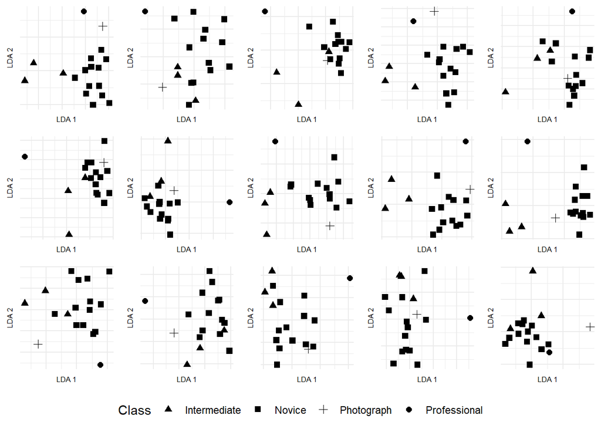

```r
handaxe5pcs <- as.data.frame(pca_handaxe$x[73:90, 1:10])
handaxe5class <- shape_data_handaxe$Class[73:90]
handaxe5pcs <- cbind(handaxe5pcs, handaxe5class)
handaxe5pcs <- rename(handaxe5pcs, Class = handaxe5class)
handaxe5lda <- lda(Class ~ ., handaxe5pcs)
handaxe5ldapredict <- predict(handaxe5lda)
handaxe5ldaplot <- cbind(handaxe5ldapredict$x[, 1:3], handaxe5pcs)
handaxe5ldaplotggplot <- ggplot(handaxe5ldaplot, aes(LD1, LD2)) +
  geom_point(aes(shape = Class), size = 2) +
  labs(x = "LDA 1", y = "LDA 2") +
  scale_shape_manual(values=c(17,15,3,16)) +
  theme_minimal() +
  theme(axis.text.x = element_blank(),
        axis.text.y = element_blank(),
        legend.position = "none",
        axis.title.y = element_text(size = 6),
        axis.title.x = element_text(size = 6))

lda.figure <-  plot_grid(elongated1ldaplotggplot,
                         elongated2ldaplotggplot,
                         elongated3ldaplotggplot,
                         elongated4ldaplotggplot,
                         elongated5ldaplotggplot,
                         tanged1ldaplotggplot,
                         tanged2ldaplotggplot,
                         tanged3ldaplotggplot,
                         tanged4ldaplotggplot,
                         tanged5ldaplotggplot,
                         handaxe1ldaplotggplot,
                         handaxe2ldaplotggplot,
                         handaxe3ldaplotggplot,
                         handaxe4ldaplotggplot,
                         handaxe5ldaplotggplot,
                         ncol = 5, align = 'v')

lda.figure.legend <- get_legend(elongated1ldaplotggplot +
                                  guides(color = guide_legend(nrow = 1)) +
                                  theme(legend.position = "bottom"))

plot_grid(lda.figure, lda.figure.legend, ncol = 1, rel_heights = c(1, .1))
```

### **Stage 6: Measurement Data (Exploratory Framework)**

To first examine the metric data, bivariate plots for all three artefact groups were generated in ggplot:

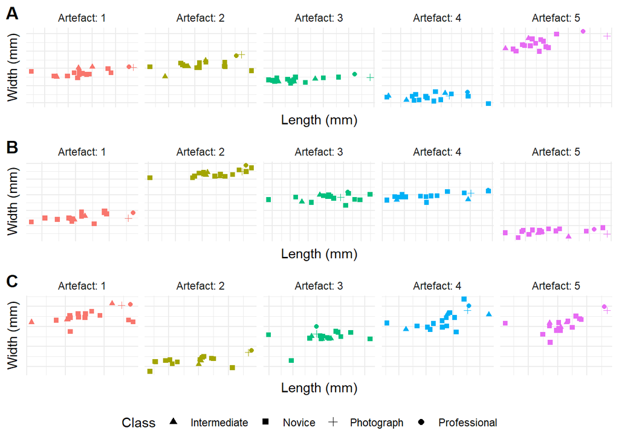

```r
metric_data_elongated <- metric_data[which(metric_data$Type=="Elongated"),]
metric_data_handaxe   <- metric_data[which(metric_data$Type=="Handaxe"),]
metric_data_tanged    <- metric_data[which(metric_data$Type=="Tanged"),]

figure_7a <- ggplot(metric_data_elongated, aes(Length_mm, Width_mm, colour = Artefact, shape = Class)) +
  geom_point() +
  facet_grid(cols = vars(Artefact), scales = "free", labeller=label_both) +
  labs(x = "Length (mm)", y = "Width (mm)") +
  scale_shape_manual(values=c(17,15,3,16)) +
  theme_minimal() +
  theme(axis.text.x = element_blank(),
        axis.text.y = element_blank(),
        legend.position = "none")

figure_7b <- ggplot(metric_data_tanged, aes(Length_mm, Width_mm, colour = Artefact, shape = Class)) +
  geom_point() +
  facet_grid(cols = vars(Artefact), scales = "free", labeller=label_both) +
  labs(x = "Length (mm)", y = "Width (mm)") +
  scale_shape_manual(values=c(17,15,3,16)) +
  theme_minimal() +
  theme(axis.text.x = element_blank(),
        axis.text.y = element_blank(),
        legend.position = "none")

figure_7c <- ggplot(metric_data_handaxe, aes(Length_mm, Width_mm, colour = Artefact, shape = Class)) +
  geom_point() +
  facet_grid(cols = vars(Artefact), scales = "free", labeller=label_both) +
  labs(x = "Length (mm)", y = "Width (mm)") +
  scale_shape_manual(values=c(17,15,3,16)) +
  theme_minimal() +
  theme(axis.text.x = element_blank(),
        axis.text.y = element_blank(),
        legend.position = "none")

figure_7 <- plot_grid(figure_7a,
                      figure_7b,
                      figure_7c,
                      labels= "AUTO",
                      ncol = 1,
                      align = 'v')

plot_grid(figure_7, lda.figure.legend, ncol = 1, rel_heights = c(1, .1))
```

### **Stage 7: Measurement Data (Analytical Framework)**

```r
metric_data_elongated <- arrange(metric_data_elongated, Artefact, Class)

metric_data_elongated[1:18,]  %>%
  group_by(Class) %>%
  summarise(count = n(),
            mean = mean(Length_mm, na.rm = TRUE),
            sd = sd(Length_mm, na.rm = TRUE),
            min = min(Length_mm, na.rm = TRUE),
            max = max(Length_mm, na.rm = TRUE),
            cv = sd(Length_mm, na.rm = TRUE)/mean(Length_mm, na.rm = TRUE)*100) %>%
  dplyr::mutate_if(is.numeric, format, 1)
```

```
## # A tibble: 4 x 7
##   Class        count mean     sd       min    max    cv
##   <chr>        <chr> <chr>    <chr>    <chr>  <chr>  <chr>
## 1 Intermediate 3     110.6033 1.516652 108.99 112.00 1.371253
## 2 Novice       13    110.8454 1.739443 106.87 113.60 1.569251
## 3 Photograph   1     115.4700 NA       115.47 115.47 NA
## 4 Professional 1     115.1400 NA       115.14 115.14 NA
```

```r
metric_data_elongated[1:18,]  %>%
  filter(Class=="Novice" | Class == "Intermediate" | Class == "Professional") %>%
  summarise(count = n(),
            cv = sd(Length_mm, na.rm = TRUE)/mean(Length_mm, na.rm = TRUE)*100) %>%
  dplyr::mutate_if(is.numeric, format, 1)
```

```
##   count       cv
## 1    17 1.725882
```

```r
metric_data_elongated[19:36,] %>%
  group_by(Class) %>%
  summarise(count = n(), mean = mean(Length_mm, na.rm = TRUE),
            sd = sd(Length_mm, na.rm = TRUE),
            min = min(Length_mm, na.rm = TRUE),
            max = max(Length_mm, na.rm = TRUE),
            cv = sd(Length_mm, na.rm = TRUE)/mean(Length_mm, na.rm = TRUE)*100) %>%
  dplyr::mutate_if(is.numeric, format, 1)
```

```
## # A tibble: 4 x 7
##   Class        count mean     sd       min    max    cv
##   <chr>        <chr> <chr>    <chr>    <chr>  <chr>  <chr>
## 1 Intermediate 3     126.6633 1.915446 124.67 128.49 1.512234
## 2 Novice       13    128.3285 2.477559 123.27 132.80 1.930639
## 3 Photograph   1     131.8400 NA       131.84 131.84 NA
## 4 Professional 1     131.3500 NA       131.35 131.35 NA
```

```r
metric_data_elongated[19:36,]  %>%
  filter(Class=="Novice" | Class == "Intermediate" | Class == "Professional") %>%
  summarise(count = n(),
            cv = sd(Length_mm, na.rm = TRUE)/mean(Length_mm, na.rm = TRUE)*100) %>%
  dplyr::mutate_if(is.numeric, format, 1)
```

```
##   count       cv
## 1    17 1.932418
```

```r
metric_data_elongated[37:54,] %>%
  group_by(Class) %>%
  summarise(count = n(),
            mean = mean(Length_mm, na.rm = TRUE),
            sd = sd(Length_mm, na.rm = TRUE),
            min = min(Length_mm, na.rm = TRUE),
            max = max(Length_mm, na.rm = TRUE),
            cv = sd(Length_mm, na.rm = TRUE)/mean(Length_mm, na.rm = TRUE)*100) %>%
  dplyr::mutate_if(is.numeric, format, 1)
```

```
## # A tibble: 4 x 7
##   Class        count mean     sd       min    max    cv
##   <chr>        <chr> <chr>    <chr>    <chr>  <chr>  <chr>
## 1 Intermediate 3     123.8233 1.464559 122.43 125.35 1.182781
## 2 Novice       13    123.6092 1.578076 121.67 127.20 1.276665
## 3 Photograph   1     129.6800 NA       129.68 129.68 NA
## 4 Professional 1     128.4700 NA       128.47 128.47 NA
```

```r
metric_data_elongated[37:54,]  %>%
  filter(Class=="Novice" | Class == "Intermediate" | Class == "Professional") %>%
  summarise(count = n(),
            cv = sd(Length_mm, na.rm = TRUE)/mean(Length_mm, na.rm = TRUE)*100) %>%
  dplyr::mutate_if(is.numeric, format, 1)
```

```
##   count       cv
## 1    17 1.511663
```

```r
metric_data_elongated[55:72,] %>%
  group_by(Class) %>%
  summarise(count = n(),
            mean = mean(Length_mm, na.rm = TRUE),
            sd = sd(Length_mm, na.rm = TRUE),
            min = min(Length_mm, na.rm = TRUE),
            max = max(Length_mm, na.rm = TRUE),
            cv = sd(Length_mm, na.rm = TRUE)/mean(Length_mm, na.rm = TRUE)*100) %>%
  dplyr::mutate_if(is.numeric, format, 1)
```

```
## # A tibble: 4 x 7
##   Class        count mean     sd       min   max   cv
##   <chr>        <chr> <chr>    <chr>    <chr> <chr> <chr>
## 1 Intermediate 3     95.60333 1.429452 94.37 97.17 1.495191
## 2 Novice       13    96.54923 1.292810 94.31 99.33 1.339016
## 3 Photograph   1     97.38000 NA       97.38 97.38 NA
## 4 Professional 1     98.30000 NA       98.30 98.30 NA
```

```r
metric_data_elongated[55:72,]  %>%
  filter(Class=="Novice" | Class == "Intermediate" | Class == "Professional") %>%
  summarise(count = n(),
            cv = sd(Length_mm, na.rm = TRUE)/mean(Length_mm, na.rm = TRUE)*100) %>%
  dplyr::mutate_if(is.numeric, format, 1)
```

```
##   count      cv
## 1    17 1.41499
```

```r
metric_data_elongated[73:90,] %>%
  group_by(Class) %>%
  summarise(count = n(),
            mean = mean(Length_mm, na.rm = TRUE),
            sd = sd(Length_mm, na.rm = TRUE),
            min = min(Length_mm, na.rm = TRUE),
            max = max(Length_mm, na.rm = TRUE),
            cv = sd(Length_mm, na.rm = TRUE)/mean(Length_mm, na.rm = TRUE)*100) %>%
  dplyr::mutate_if(is.numeric, format, 1)
```

```
## # A tibble: 4 x 7
##   Class        count mean   sd       min    max    cv
##   <chr>        <chr> <chr>  <chr>    <chr>  <chr>  <chr>
## 1 Intermediate 3     181.76 1.408226 180.17 182.85 0.7747721
## 2 Novice       13    183.56 1.501927 181.08 186.11 0.8182210
## 3 Photograph   1     191.97 NA       191.97 191.97 NA
## 4 Professional 1     189.22 NA       189.22 189.22 NA
```

```r
metric_data_elongated[73:90,]  %>%
  filter(Class=="Novice" | Class == "Intermediate" | Class == "Professional") %>%
  summarise(count = n(),
            cv = sd(Length_mm, na.rm = TRUE)/mean(Length_mm, na.rm = TRUE)*100) %>%
  dplyr::mutate_if(is.numeric, format, 1)
```

```
##   count       cv
## 1    17 1.161859
```

```r
shapiro.test(metric_data_elongated$Length_mm[2:4])
```

```
##
##  Shapiro-Wilk normality test
##
## data:  metric_data_elongated$Length_mm[2:4]
## W = 0.994, p-value = 0.8519
```

```r
shapiro.test(metric_data_elongated$Width_mm[2:4])
```

```
##
##  Shapiro-Wilk normality test
##
## data:  metric_data_elongated$Width_mm[2:4]
## W = 0.8097, p-value = 0.1379
```

```r
shapiro.test(metric_data_elongated$Length_mm[5:17])
```

```
##
##  Shapiro-Wilk normality test
##
## data:  metric_data_elongated$Length_mm[5:17]
## W = 0.93829, p-value = 0.4352
```

```r
shapiro.test(metric_data_elongated$Width_mm[5:17])
```

```
##
##  Shapiro-Wilk normality test
##
## data:  metric_data_elongated$Width_mm[5:17]
## W = 0.95188, p-value = 0.6271
```

```r
shapiro.test(metric_data_elongated$Length_mm[20:22])
```

```
##
##  Shapiro-Wilk normality test
##
## data:  metric_data_elongated$Length_mm[20:22]
## W = 0.86266, p-value = 0.2749
```

```r
shapiro.test(metric_data_elongated$Width_mm[20:22])
```

```
##
##  Shapiro-Wilk normality test
##
## data:  metric_data_elongated$Width_mm[20:22]
## W = 0.99576, p-value = 0.8755
```

```r
shapiro.test(metric_data_elongated$Length_mm[23:35])
```

```
##
##  Shapiro-Wilk normality test
##
## data:  metric_data_elongated$Length_mm[23:35]
## W = 0.9602, p-value = 0.7568
```

```r
shapiro.test(metric_data_elongated$Width_mm[23:35])
```

```
##
##  Shapiro-Wilk normality test
##
## data:  metric_data_elongated$Width_mm[23:35]
## W = 0.88869, p-value = 0.0936
```

```r
shapiro.test(metric_data_elongated$Length_mm[38:40])
```

```
##
##  Shapiro-Wilk normality test
##
## data:  metric_data_elongated$Length_mm[38:40]
## W = 0.87597, p-value = 0.3127
```

```r
shapiro.test(metric_data_elongated$Width_mm[38:40])
```

```
##
##  Shapiro-Wilk normality test
##
## data:  metric_data_elongated$Width_mm[38:40]
## W = 0.93589, p-value = 0.5111
```

```r
shapiro.test(metric_data_elongated$Length_mm[41:53])
```

```
##
##  Shapiro-Wilk normality test
##
## data:  metric_data_elongated$Length_mm[41:53]
## W = 0.86234, p-value = 0.04136
```

```r
shapiro.test(metric_data_elongated$Width_mm[41:53])
```

```
##
##  Shapiro-Wilk normality test
##
## data:  metric_data_elongated$Width_mm[41:53]
## W = 0.92754, p-value = 0.3164
```

```r
shapiro.test(metric_data_elongated$Length_mm[56:58])
```

```
##
##  Shapiro-Wilk normality test
##
## data:  metric_data_elongated$Length_mm[56:58]
## W = 0.91854, p-value = 0.4472
```

```r
shapiro.test(metric_data_elongated$Width_mm[56:58])
```

```
##
##  Shapiro-Wilk normality test
##
## data:  metric_data_elongated$Width_mm[56:58]
## W = 0.90007, p-value = 0.3857
```

```r
shapiro.test(metric_data_elongated$Length_mm[59:71])
```

```
##
##  Shapiro-Wilk normality test
##
## data:  metric_data_elongated$Length_mm[59:71]
## W = 0.97937, p-value = 0.9763
```

```r
shapiro.test(metric_data_elongated$Width_mm[59:71])
```

```
##
##  Shapiro-Wilk normality test
##
## data:  metric_data_elongated$Width_mm[59:71]
## W = 0.98079, p-value = 0.9831
```

```r
shapiro.test(metric_data_elongated$Length_mm[74:76])
```

```
##
##  Shapiro-Wilk normality test
##
## data:  metric_data_elongated$Length_mm[74:76]
## W = 0.80888, p-value = 0.1359
```

```r
shapiro.test(metric_data_elongated$Width_mm[74:76])
```

```
##
##  Shapiro-Wilk normality test
##
## data:  metric_data_elongated$Width_mm[74:76]
## W = 0.93099, p-value = 0.4923
```

```r
shapiro.test(metric_data_elongated$Length_mm[77:89])
```

```
##
##  Shapiro-Wilk normality test
##
## data:  metric_data_elongated$Length_mm[77:89]
## W = 0.83103, p-value = 0.01632
```

```r
shapiro.test(metric_data_elongated$Width_mm[77:89])
```

```
##
##  Shapiro-Wilk normality test
##
## data:  metric_data_elongated$Width_mm[77:89]
## W = 0.95961, p-value = 0.7476
```

```r
summary(manova(cbind(Length_mm, Width_mm) ~ Class,
               data = metric_data_elongated[1:18,]))
```

```
##           Df Pillai approx F num Df den Df  Pr(>F)
## Class      3 0.7104   2.5707      6     28 0.04128 *
## Residuals 14
## ---
## Signif. codes:  0 '***' 0.001 '**' 0.01 '*' 0.05 '.' 0.1 ' ' 1
```

```r
summary.aov(manova(cbind(Length_mm, Width_mm) ~ Class,
                   data = metric_data_elongated[1:18,]))
```

```
##  Response Length_mm :
##             Df Sum Sq Mean Sq F value  Pr(>F)
## Class        3 36.277  12.092  4.1384 0.02699 *
## Residuals   14 40.908   2.922
## ---
## Signif. codes:  0 '***' 0.001 '**' 0.01 '*' 0.05 '.' 0.1 ' ' 1
##
##  Response Width_mm :
##             Df Sum Sq Mean Sq F value  Pr(>F)
## Class        3 30.542 10.1808  3.4272 0.04676 *
## Residuals   14 41.588  2.9706
## ---
## Signif. codes:  0 '***' 0.001 '**' 0.01 '*' 0.05 '.' 0.1 ' ' 1
```

```r
summary(manova(cbind(Length_mm, Width_mm) ~ Class,
               data = metric_data_elongated[19:36,]))
```

```
##           Df  Pillai approx F num Df den Df Pr(>F)
## Class      3 0.59119   1.9583      6     28  0.106
## Residuals 14
```

```r
summary.aov(manova(cbind(Length_mm, Width_mm) ~ Class,
                   data = metric_data_elongated[19:36,]))
```

```
##  Response Length_mm :
##             Df Sum Sq Mean Sq F value Pr(>F)
## Class        3 29.647  9.8824  1.7081  0.211
## Residuals   14 80.997  5.7855
##
##  Response Width_mm :
##             Df Sum Sq Mean Sq F value  Pr(>F)
## Class        3 74.511 24.8370  5.0069 0.01451 *
## Residuals   14 69.448  4.9606
## ---
## Signif. codes:  0 '***' 0.001 '**' 0.01 '*' 0.05 '.' 0.1 ' ' 1
```

```r
summary(manova(cbind(Length_mm, Width_mm) ~ Class,
               data = metric_data_elongated[37:54,]))
```

```
##           Df  Pillai approx F num Df den Df  Pr(>F)
## Class      3 0.78278   3.0011      6     28 0.02159 *
## Residuals 14
## ---
## Signif. codes:  0 '***' 0.001 '**' 0.01 '*' 0.05 '.' 0.1 ' ' 1
```

```r
summary.aov(manova(cbind(Length_mm, Width_mm) ~ Class,
                   data = metric_data_elongated[37:54,]))
```

```
##  Response Length_mm :
##             Df Sum Sq Mean Sq F value   Pr(>F)
## Class        3 53.177  17.726  7.2617 0.003573 **
## Residuals   14 34.174   2.441
## ---
## Signif. codes:  0 '***' 0.001 '**' 0.01 '*' 0.05 '.' 0.1 ' ' 1
##
##  Response Width_mm :
##             Df Sum Sq Mean Sq F value  Pr(>F)
## Class        3 11.829  3.9430  3.2225 0.05519 .
## Residuals   14 17.130  1.2236
## ---
## Signif. codes:  0 '***' 0.001 '**' 0.01 '*' 0.05 '.' 0.1 ' ' 1
```

```r
summary(manova(cbind(Length_mm, Width_mm) ~ Class,
               data = metric_data_elongated[55:72,]))
```

```
##           Df  Pillai approx F num Df den Df Pr(>F)
## Class      3 0.37886   1.0906      6     28 0.3922
## Residuals 14
```

```r
summary.aov(manova(cbind(Length_mm, Width_mm) ~ Class,
                   data = metric_data_elongated[55:72,]))
```

```
##  Response Length_mm :
##             Df  Sum Sq Mean Sq F value Pr(>F)
## Class        3  6.4359  2.1453   1.244 0.3312
## Residuals   14 24.1430  1.7245
##
##  Response Width_mm :
##             Df Sum Sq Mean Sq F value Pr(>F)
## Class        3 10.653  3.5511  0.9591 0.4392
## Residuals   14 51.837  3.7026
```

```r
summary(manova(cbind(Length_mm, Width_mm) ~ Class,
               data = metric_data_elongated[73:90,]))
```

```
##           Df  Pillai approx F num Df den Df   Pr(>F)
## Class      3 0.96814   4.3785      6     28 0.003066 **
## Residuals 14
## ---
## Signif. codes:  0 '***' 0.001 '**' 0.01 '*' 0.05 '.' 0.1 ' ' 1
```

```r
summary.aov(manova(cbind(Length_mm, Width_mm) ~ Class,
                   data = metric_data_elongated[73:90,]))
```

```
##  Response Length_mm :
##             Df  Sum Sq Mean Sq F value    Pr(>F)
## Class        3 108.308  36.103  16.286 7.665e-05 ***
## Residuals   14  31.036   2.217
## ---
## Signif. codes:  0 '***' 0.001 '**' 0.01 '*' 0.05 '.' 0.1 ' ' 1
##
##  Response Width_mm :
##             Df  Sum Sq Mean Sq F value  Pr(>F)
## Class        3  74.424 24.8082   2.875 0.07372 .
## Residuals   14 120.803  8.6288
## ---
## Signif. codes:  0 '***' 0.001 '**' 0.01 '*' 0.05 '.' 0.1 ' ' 1
```

```r
metric_data_handaxe <- arrange(metric_data_handaxe, Artefact, Class)

metric_data_handaxe[1:18,]  %>%
  group_by(Class) %>%
  summarise(count = n(),
            mean = mean(Length_mm, na.rm = TRUE),
            sd = sd(Length_mm, na.rm = TRUE),
            min = min(Length_mm, na.rm = TRUE),
            max = max(Length_mm, na.rm = TRUE),
            cv = sd(Length_mm, na.rm = TRUE)/mean(Length_mm, na.rm = TRUE)*100) %>%
  dplyr::mutate_if(is.numeric, format, 1)
```

```
## # A tibble: 4 x 7
##   Class        count mean     sd       min    max    cv
##   <chr>        <chr> <chr>    <chr>    <chr>  <chr>  <chr>
## 1 Intermediate 3     115.6233 5.201167 110.63 121.01 4.498371
## 2 Novice       13    117.6562 2.969151 113.84 123.76 2.523583
## 3 Photograph   1     122.2600 NA       122.26 122.26 NA
## 4 Professional 1     123.4300 NA       123.43 123.43 NA
```

```r
metric_data_handaxe[1:18,]  %>%
  filter(Class=="Novice" | Class == "Intermediate" | Class == "Professional") %>%
  summarise(count = n(),
            cv = sd(Length_mm, na.rm = TRUE)/mean(Length_mm, na.rm = TRUE)*100) %>%
  dplyr::mutate_if(is.numeric, format, 1)
```

```
##   count       cv
## 1    17 3.047414
```

```r
metric_data_handaxe[19:36,] %>%
  group_by(Class) %>%
  summarise(count = n(),
            mean = mean(Length_mm, na.rm = TRUE),
            sd = sd(Length_mm, na.rm = TRUE),
            min = min(Length_mm, na.rm = TRUE),
            max = max(Length_mm, na.rm = TRUE),
            cv = sd(Length_mm, na.rm = TRUE)/mean(Length_mm, na.rm = TRUE)*100) %>%
  dplyr::mutate_if(is.numeric, format, 1)
```

```
## # A tibble: 4 x 7
##   Class        count mean     sd       min    max    cv
##   <chr>        <chr> <chr>    <chr>    <chr>  <chr>  <chr>
## 1 Intermediate 3     102.0900 0.080000 102.01 102.17 0.07836223
## 2 Novice       13    101.1138 1.780503 98.74  104.27 1.76088978
## 3 Photograph   1     105.3500 NA       105.35 105.35 NA
## 4 Professional 1     105.5600 NA       105.56 105.56 NA
```

```r
metric_data_handaxe[19:36,]  %>%
  filter(Class=="Novice" | Class == "Intermediate" | Class == "Professional") %>%
  summarise(count = n(),
            cv = sd(Length_mm, na.rm = TRUE)/mean(Length_mm, na.rm = TRUE)*100) %>%
  dplyr::mutate_if(is.numeric, format, 1)
```

```
##   count       cv
## 1    17 1.866549
```

```r
metric_data_handaxe[37:54,] %>%
  group_by(Class) %>%
  summarise(count = n(), mean = mean(Length_mm, na.rm = TRUE), sd = sd(Length_mm, na.rm = TRUE), min = min(Length_mm, na.rm = TRUE), max = max(Length_mm, na.rm = TRUE), cv = sd(Length_mm, na.rm = TRUE)/mean(Length_mm, na.rm = TRUE)*100) %>%
  dplyr::mutate_if(is.numeric, format, 1)
```

```
## # A tibble: 4 x 7
##   Class        count mean     sd       min    max    cv
##   <chr>        <chr> <chr>    <chr>    <chr>  <chr>  <chr>
## 1 Intermediate 3     102.9600 1.015923 101.92 103.95 0.9867164
## 2 Novice       13    103.3415 2.663196 97.45  108.02 2.5770820
## 3 Photograph   1     102.4300 NA       102.43 102.43 NA
## 4 Professional 1     102.4400 NA       102.44 102.44 NA
```

```r
metric_data_handaxe[37:54,]  %>%
  filter(Class=="Novice" | Class == "Intermediate" | Class == "Professional") %>%
  summarise(count = n(), cv = sd(Length_mm, na.rm = TRUE)/mean(Length_mm, na.rm = TRUE)*100) %>%
  dplyr::mutate_if(is.numeric, format, 1)
```

```
##   count       cv
## 1    17 2.274329
```

```r
metric_data_handaxe[55:72,] %>%
  group_by(Class) %>%
  summarise(count = n(),
            mean = mean(Length_mm, na.rm = TRUE),
            sd = sd(Length_mm, na.rm = TRUE),
            min = min(Length_mm, na.rm = TRUE),
            max = max(Length_mm, na.rm = TRUE),
            cv = sd(Length_mm, na.rm = TRUE)/mean(Length_mm, na.rm = TRUE)*100) %>%
  dplyr::mutate_if(is.numeric, format, 1)
```

```
## # A tibble: 4 x 7
##   Class        count mean     sd       min    max    cv
##   <chr>        <chr> <chr>    <chr>    <chr>  <chr>  <chr>
## 1 Intermediate 3     188.9167 7.650054 181.25 196.55 4.049433
## 2 Novice       13    187.2654 3.720118 177.76 192.04 1.986549
## 3 Photograph   1     192.6300 NA       192.63 192.63 NA
## 4 Professional 1     192.8800 NA       192.88 192.88 NA
```

```r
metric_data_handaxe[55:72,]  %>%
  filter(Class=="Novice" | Class == "Intermediate" | Class == "Professional") %>%
  summarise(count = n(),
            cv = sd(Length_mm, na.rm = TRUE)/mean(Length_mm, na.rm = TRUE)*100) %>%
  dplyr::mutate_if(is.numeric, format, 1)
```

```
##   count       cv
## 1    17 2.366245
```

```r
metric_data_handaxe[73:90,] %>%
  group_by(Class) %>%
  summarise(count = n(),
            mean = mean(Length_mm, na.rm = TRUE),
            sd = sd(Length_mm, na.rm = TRUE),
            min = min(Length_mm, na.rm = TRUE),
            max = max(Length_mm, na.rm = TRUE),
            cv = sd(Length_mm, na.rm = TRUE)/mean(Length_mm, na.rm = TRUE)*100) %>%
  dplyr::mutate_if(is.numeric, format, 1)
```

```
## # A tibble: 4 x 7
##   Class        count mean     sd       min    max    cv
##   <chr>        <chr> <chr>    <chr>    <chr>  <chr>  <chr>
## 1 Intermediate 3     180.1900 1.185411 178.91 181.25 0.6578674
## 2 Novice       13    180.1177 2.722349 172.88 183.23 1.5114281
## 3 Photograph   1     186.7500 NA       186.75 186.75 NA
## 4 Professional 1     186.3700 NA       186.37 186.37 NA
```

```r
metric_data_handaxe[73:90,]  %>%
  filter(Class=="Novice" | Class == "Intermediate" | Class == "Professional") %>%
  summarise(count = n(),
            cv = sd(Length_mm, na.rm = TRUE)/mean(Length_mm, na.rm = TRUE)*100) %>%
  dplyr::mutate_if(is.numeric, format, 1)
```

```
##   count       cv
## 1    17 1.569395
```

```r
shapiro.test(metric_data_handaxe$Length_mm[2:4])
```

```
##
##  Shapiro-Wilk normality test
##
## data:  metric_data_handaxe$Length_mm[2:4]
## W = 0.85647, p-value = 0.2579
```

```r
shapiro.test(metric_data_handaxe$Width_mm[2:4])
```

```
##
##  Shapiro-Wilk normality test
##
## data:  metric_data_handaxe$Width_mm[2:4]
## W = 0.97381, p-value = 0.6896
```

```r
shapiro.test(metric_data_handaxe$Length_mm[5:17])
```

```
##
##  Shapiro-Wilk normality test
##
## data:  metric_data_handaxe$Length_mm[5:17]
## W = 0.85528, p-value = 0.0334
```

```r
shapiro.test(metric_data_handaxe$Width_mm[5:17])
```

```
##
##  Shapiro-Wilk normality test
##
## data:  metric_data_handaxe$Width_mm[5:17]
## W = 0.94153, p-value = 0.4771
```

```r
shapiro.test(metric_data_handaxe$Length_mm[20:22])
```

```
##
##  Shapiro-Wilk normality test
##
## data:  metric_data_handaxe$Length_mm[20:22]
## W = 0.80959, p-value = 0.1376
```

```r
shapiro.test(metric_data_handaxe$Width_mm[20:22])
```

```
##
##  Shapiro-Wilk normality test
##
## data:  metric_data_handaxe$Width_mm[20:22]
## W = 0.75, p-value < 2.2e-16
```

```r
shapiro.test(metric_data_handaxe$Length_mm[23:35])
```

```
##
##  Shapiro-Wilk normality test
##
## data:  metric_data_handaxe$Length_mm[23:35]
## W = 0.92891, p-value = 0.3298
```

```r
shapiro.test(metric_data_handaxe$Width_mm[23:35])
```

```
##
##  Shapiro-Wilk normality test
##
## data:  metric_data_handaxe$Width_mm[23:35]
## W = 0.95638, p-value = 0.6972
```

```r
shapiro.test(metric_data_handaxe$Length_mm[38:40])
```

```
##
##  Shapiro-Wilk normality test
##
## data:  metric_data_handaxe$Length_mm[38:40]
## W = 0.99997, p-value = 0.9892
```

```r
shapiro.test(metric_data_handaxe$Width_mm[38:40])
```

```
##
##  Shapiro-Wilk normality test
##
## data:  metric_data_handaxe$Width_mm[38:40]
## W = 0.98821, p-value = 0.7922
```

```r
shapiro.test(metric_data_handaxe$Length_mm[41:53])
```

```
##
##  Shapiro-Wilk normality test
##
## data:  metric_data_handaxe$Length_mm[41:53]
## W = 0.94426, p-value = 0.5144
```

```r
shapiro.test(metric_data_handaxe$Width_mm[41:53])
```

```
##
##  Shapiro-Wilk normality test
##
## data:  metric_data_handaxe$Width_mm[41:53]
## W = 0.64516, p-value = 0.0001654
```

```r
shapiro.test(metric_data_handaxe$Length_mm[56:58])
```

```
##
##  Shapiro-Wilk normality test
##
## data:  metric_data_handaxe$Length_mm[56:58]
## W = 0.99874, p-value = 0.9323
```

```r
shapiro.test(metric_data_handaxe$Width_mm[56:58])
```

```
##
##  Shapiro-Wilk normality test
##
## data:  metric_data_handaxe$Width_mm[56:58]
## W = 0.83824, p-value = 0.2095
```

```r
shapiro.test(metric_data_handaxe$Length_mm[59:71])
```

```
##
##  Shapiro-Wilk normality test
##
## data:  metric_data_handaxe$Length_mm[59:71]
## W = 0.923, p-value = 0.2753
```

```r
shapiro.test(metric_data_handaxe$Width_mm[59:71])
```

```
##
##  Shapiro-Wilk normality test
##
## data:  metric_data_handaxe$Width_mm[59:71]
## W = 0.87222, p-value = 0.05601
```

```r
shapiro.test(metric_data_handaxe$Length_mm[74:76])
```

```
##
##  Shapiro-Wilk normality test
##
## data:  metric_data_handaxe$Length_mm[74:76]
## W = 0.92031, p-value = 0.4534
```

```r
shapiro.test(metric_data_handaxe$Width_mm[74:76])
```

```
##
##  Shapiro-Wilk normality test
##
## data:  metric_data_handaxe$Width_mm[74:76]
## W = 0.80075, p-value = 0.1163
```

```r
shapiro.test(metric_data_handaxe$Length_mm[77:89])
```

```
##
##  Shapiro-Wilk normality test
##
## data:  metric_data_handaxe$Length_mm[77:89]
## W = 0.94055, p-value = 0.464
```

```r
shapiro.test(metric_data_handaxe$Width_mm[77:89])
```

```
##
##  Shapiro-Wilk normality test
##
## data:  metric_data_handaxe$Width_mm[77:89]
## W = 0.98557, p-value = 0.9964
```

```r
summary(manova(cbind(Length_mm, Width_mm) ~ Class,
               data = metric_data_handaxe[1:18,]))
```

```
##           Df  Pillai approx F num Df den Df Pr(>F)
## Class      3 0.54763   1.7596      6     28 0.1441
## Residuals 14
```

```r
summary.aov(manova(cbind(Length_mm, Width_mm) ~ Class,
                   data = metric_data_handaxe[1:18,]))
```

```
##  Response Length_mm :
##             Df  Sum Sq Mean Sq F value Pr(>F)
## Class        3  65.912  21.971  1.9237 0.1722
## Residuals   14 159.895  11.421
##
##  Response Width_mm :
##             Df  Sum Sq Mean Sq F value  Pr(>F)
## Class        3  76.939 25.6464  2.8436 0.07571 .
## Residuals   14 126.264  9.0189
## ---
## Signif. codes:  0 '***' 0.001 '**' 0.01 '*' 0.05 '.' 0.1 ' ' 1
```

```r
summary(manova(cbind(Length_mm, Width_mm) ~ Class,
               data = metric_data_handaxe[19:36,]))
```

```
##           Df  Pillai approx F num Df den Df Pr(>F)
## Class      3 0.59356   1.9695      6     28 0.1042
## Residuals 14
```

```r
summary.aov(manova(cbind(Length_mm, Width_mm) ~ Class,
                   data = metric_data_handaxe[19:36,]))
```

```
##  Response Length_mm :
##             Df Sum Sq Mean Sq F value  Pr(>F)
## Class        3 33.082 11.0275  4.0569 0.02869 *
## Residuals   14 38.055  2.7182
## ---
## Signif. codes:  0 '***' 0.001 '**' 0.01 '*' 0.05 '.' 0.1 ' ' 1
##
##  Response Width_mm :
##             Df Sum Sq Mean Sq F value  Pr(>F)
## Class        3 45.094 15.0313  3.6851 0.03813 *
## Residuals   14 57.105  4.0789
## ---
## Signif. codes:  0 '***' 0.001 '**' 0.01 '*' 0.05 '.' 0.1 ' ' 1
```

```r
adonis(cbind(Length_mm, Width_mm) ~ Class,
       data = metric_data_handaxe[37:54,])
```

```
##
## Call:
## adonis(formula = cbind(Length_mm, Width_mm) ~ Class, data = metric_data_handaxe[37:54,      ])
##
## Permutation: free
## Number of permutations: 999
##
## Terms added sequentially (first to last)
##
##           Df SumsOfSqs    MeanSqs F.Model      R2 Pr(>F)
## Class      3 0.0003423 0.00011411 0.49079 0.09516  0.613
## Residuals 14 0.0032550 0.00023250         0.90484
## Total     17 0.0035973                    1.00000
```

```r
summary(manova(cbind(Length_mm, Width_mm) ~ Class,
               data = metric_data_handaxe[55:72,]))
```

```
##           Df  Pillai approx F num Df den Df Pr(>F)
## Class      3 0.27216  0.73507      6     28 0.6256
## Residuals 14
```

```r
summary.aov(manova(cbind(Length_mm, Width_mm) ~ Class,
                   data = metric_data_handaxe[55:72,]))
```

```
##  Response Length_mm :
##             Df Sum Sq Mean Sq F value Pr(>F)
## Class        3  54.38  18.127  0.8963 0.4674
## Residuals   14 283.12  20.223
##
##  Response Width_mm :
##             Df  Sum Sq Mean Sq F value Pr(>F)
## Class        3  84.734  28.245  1.5192 0.2531
## Residuals   14 260.287  18.592
```

```r
summary(manova(cbind(Length_mm, Width_mm) ~ Class,
               data = metric_data_handaxe[73:90,]))
```

```
##           Df  Pillai approx F num Df den Df Pr(>F)
## Class      3 0.57182   1.8685      6     28 0.1218
## Residuals 14
```

```r
summary.aov(manova(cbind(Length_mm, Width_mm) ~ Class,
                   data = metric_data_handaxe[73:90,]))
```

```
##  Response Length_mm :
##             Df Sum Sq Mean Sq F value Pr(>F)
## Class        3 73.558 24.5195  3.7416 0.0365 *
## Residuals   14 91.745  6.5532
## ---
## Signif. codes:  0 '***' 0.001 '**' 0.01 '*' 0.05 '.' 0.1 ' ' 1
##
##  Response Width_mm :
##             Df Sum Sq Mean Sq F value  Pr(>F)
## Class        3 135.10  45.034  3.9909 0.03015 *
## Residuals   14 157.98  11.284
## ---
## Signif. codes:  0 '***' 0.001 '**' 0.01 '*' 0.05 '.' 0.1 ' ' 1
```

```r
metric_data_tanged <- arrange(metric_data_tanged, Artefact, Class)

metric_data_tanged[1:18,]  %>%
  group_by(Class) %>%
  summarise(count = n(),
            mean = mean(Length_mm, na.rm = TRUE),
            sd = sd(Length_mm, na.rm = TRUE),
            min = min(Length_mm, na.rm = TRUE),
            max = max(Length_mm, na.rm = TRUE),
            cv = sd(Length_mm, na.rm = TRUE)/mean(Length_mm, na.rm = TRUE)*100) %>%
  dplyr::mutate_if(is.numeric, format, 1)
```

```
## # A tibble: 4 x 7
##   Class        count mean     sd        min   max   cv
##   <chr>        <chr> <chr>    <chr>     <chr> <chr> <chr>
## 1 Intermediate 3     84.07333 0.4119871 83.76 84.54 0.490033
## 2 Novice       13    84.19154 1.4370679 81.38 85.84 1.706903
## 3 Photograph   1     87.12000 NA        87.12 87.12 NA
## 4 Professional 1     87.41000 NA        87.41 87.41 NA
```

```r
metric_data_tanged[1:18,]  %>%
  filter(Class=="Novice" | Class == "Intermediate" | Class == "Professional") %>%
  summarise(count = n(),
            cv = sd(Length_mm, na.rm = TRUE)/mean(Length_mm, na.rm = TRUE)*100) %>%
  dplyr::mutate_if(is.numeric, format, 1)
```

```
##   count       cv
## 1    17 1.754211
```

```r
metric_data_tanged[19:36,] %>%
  group_by(Class) %>%
  summarise(count = n(),
            mean = mean(Length_mm, na.rm = TRUE),
            sd = sd(Length_mm, na.rm = TRUE),
            min = min(Length_mm, na.rm = TRUE),
            max = max(Length_mm, na.rm = TRUE),
            cv = sd(Length_mm, na.rm = TRUE)/mean(Length_mm, na.rm = TRUE)*100) %>%
  dplyr::mutate_if(is.numeric, format, 1)
```

```
## # A tibble: 4 x 7
##   Class        count mean     sd        min    max    cv
##   <chr>        <chr> <chr>    <chr>     <chr>  <chr>  <chr>
## 1 Intermediate 3     105.6333 0.5614564 105.27 106.28 0.5315145
## 2 Novice       13    105.8038 2.0141356 101.13 108.62 1.9036507
## 3 Photograph   1     107.9200 NA        107.92 107.92 NA
## 4 Professional 1     108.2000 NA        108.20 108.20 NA
```

```r
metric_data_tanged[19:36,]  %>%
  filter(Class=="Novice" | Class == "Intermediate" | Class == "Professional") %>%
  summarise(count = n(), cv = sd(Length_mm, na.rm = TRUE)/mean(Length_mm, na.rm = TRUE)*100) %>%
  dplyr::mutate_if(is.numeric, format, 1)
```

```
##   count       cv
## 1    17 1.749417
```

```r
metric_data_tanged[37:54,] %>%
  group_by(Class) %>%
  summarise(count = n(),
            mean = mean(Length_mm, na.rm = TRUE),
            sd = sd(Length_mm, na.rm = TRUE),
            min = min(Length_mm, na.rm = TRUE),
            max = max(Length_mm, na.rm = TRUE),
            cv = sd(Length_mm, na.rm = TRUE)/mean(Length_mm, na.rm = TRUE)*100) %>%
  dplyr::mutate_if(is.numeric, format, 1)
```

```
## # A tibble: 4 x 7
##   Class        count mean     sd        min   max   cv
##   <chr>        <chr> <chr>    <chr>     <chr> <chr> <chr>
## 1 Intermediate 3     87.53000 0.8166395 86.66 88.28 0.9329824
## 2 Novice       13    88.27692 1.5441901 84.78 90.49 1.7492568
## 3 Photograph   1     88.83000 NA        88.83 88.83 NA
## 4 Professional 1     89.23000 NA        89.23 89.23 NA
```

```r
metric_data_tanged[37:54,]  %>%
  filter(Class=="Novice" | Class == "Intermediate" | Class == "Professional") %>%
  summarise(count = n(),
            cv = sd(Length_mm, na.rm = TRUE)/mean(Length_mm, na.rm = TRUE)*100) %>%
  dplyr::mutate_if(is.numeric, format, 1)
```

```
##   count       cv
## 1    17 1.614196
```

```r
metric_data_tanged[55:72,] %>%
  group_by(Class) %>%
  summarise(count = n(),
            mean = mean(Length_mm, na.rm = TRUE),
            sd = sd(Length_mm, na.rm = TRUE),
            min = min(Length_mm, na.rm = TRUE),
            max = max(Length_mm, na.rm = TRUE),
            cv = sd(Length_mm, na.rm = TRUE)/mean(Length_mm, na.rm = TRUE)*100) %>%
  dplyr::mutate_if(is.numeric, format, 1)
```

```
## # A tibble: 4 x 7
##   Class        count mean     sd       min   max   cv
##   <chr>        <chr> <chr>    <chr>    <chr> <chr> <chr>
## 1 Intermediate 3     54.83000 1.783003 53.64 56.88 3.251875
## 2 Novice       13    54.95231 1.324425 53.20 57.82 2.410136
## 3 Photograph   1     57.01000 NA       57.01 57.01 NA
## 4 Professional 1     57.80000 NA       57.80 57.80 NA
```

```r
metric_data_tanged[55:72,]  %>%
  filter(Class=="Novice" | Class == "Intermediate" | Class == "Professional") %>%
  summarise(count = n(),
            cv = sd(Length_mm, na.rm = TRUE)/mean(Length_mm, na.rm = TRUE)*100) %>%
  dplyr::mutate_if(is.numeric, format, 1)
```

```
##   count       cv
## 1    17 2.691978
```

```r
metric_data_tanged[73:90,] %>%
  group_by(Class) %>%
  summarise(count = n(),
            mean = mean(Length_mm, na.rm = TRUE),
            sd = sd(Length_mm, na.rm = TRUE),
            min = min(Length_mm, na.rm = TRUE),
            max = max(Length_mm, na.rm = TRUE),
            cv = sd(Length_mm, na.rm = TRUE)/mean(Length_mm, na.rm = TRUE)*100) %>%
  dplyr::mutate_if(is.numeric, format, 1)
```

```
## # A tibble: 4 x 7
##   Class        count mean     sd        min   max   cv
##   <chr>        <chr> <chr>    <chr>     <chr> <chr> <chr>
## 1 Intermediate 3     60.11000 0.7754354 59.58 61.00 1.290027
## 2 Novice       13    59.83846 1.2881631 58.06 62.62 2.152734
## 3 Photograph   1     62.81000 NA        62.81 62.81 NA
## 4 Professional 1     62.22000 NA        62.22 62.22 NA
```

```r
metric_data_tanged[73:90,]  %>%
  filter(Class=="Novice" | Class == "Intermediate" | Class == "Professional") %>%
  summarise(count = n(),
            cv = sd(Length_mm, na.rm = TRUE)/mean(Length_mm, na.rm = TRUE)*100) %>%
  dplyr::mutate_if(is.numeric, format, 1)
```

```
##   count       cv
## 1    17 2.140211
```

```r
shapiro.test(metric_data_tanged$Length_mm[2:4])
```

```
##
##  Shapiro-Wilk normality test
##
## data:  metric_data_tanged$Length_mm[2:4]
## W = 0.95243, p-value = 0.5801
```

```r
shapiro.test(metric_data_tanged$Width_mm[2:4])
```

```
##
##  Shapiro-Wilk normality test
##
## data:  metric_data_tanged$Width_mm[2:4]
## W = 0.99986, p-value = 0.9773
```

```r
shapiro.test(metric_data_tanged$Length_mm[5:17])
```

```
##
##  Shapiro-Wilk normality test
##
## data:  metric_data_tanged$Length_mm[5:17]
## W = 0.96154, p-value = 0.7772
```

```r
shapiro.test(metric_data_tanged$Width_mm[5:17])
```

```
##
##  Shapiro-Wilk normality test
##
## data:  metric_data_tanged$Width_mm[5:17]
## W = 0.94549, p-value = 0.5318
```

```r
shapiro.test(metric_data_tanged$Length_mm[20:22])
```

```
##
##  Shapiro-Wilk normality test
##
## data:  metric_data_tanged$Length_mm[20:22]
## W = 0.99957, p-value = 0.9604
```

```r
shapiro.test(metric_data_tanged$Width_mm[20:22])
```

```
##
##  Shapiro-Wilk normality test
##
## data:  metric_data_tanged$Width_mm[20:22]
## W = 0.85465, p-value = 0.253
```

```r
shapiro.test(metric_data_tanged$Length_mm[23:35])
```

```
##
##  Shapiro-Wilk normality test
##
## data:  metric_data_tanged$Length_mm[23:35]
## W = 0.93546, p-value = 0.4009
```

```r
shapiro.test(metric_data_tanged$Width_mm[23:35])
```

```
##
##  Shapiro-Wilk normality test
##
## data:  metric_data_tanged$Width_mm[23:35]
## W = 0.95349, p-value = 0.652
```

```r
shapiro.test(metric_data_tanged$Length_mm[38:40])
```

```
##
##  Shapiro-Wilk normality test
##
## data:  metric_data_tanged$Length_mm[38:40]
## W = 0.93746, p-value = 0.5173
```

```r
shapiro.test(metric_data_tanged$Width_mm[38:40])
```

```
##
##  Shapiro-Wilk normality test
##
## data:  metric_data_tanged$Width_mm[38:40]
## W = 0.99882, p-value = 0.9344
```

```r
shapiro.test(metric_data_tanged$Length_mm[41:53])
```

```
##
##  Shapiro-Wilk normality test
##
## data:  metric_data_tanged$Length_mm[41:53]
## W = 0.946, p-value = 0.5391
```

```r
shapiro.test(metric_data_tanged$Width_mm[41:53])
```

```
##
##  Shapiro-Wilk normality test
##
## data:  metric_data_tanged$Width_mm[41:53]
## W = 0.91872, p-value = 0.2411
```

```r
shapiro.test(metric_data_tanged$Length_mm[56:58])
```

```
##
##  Shapiro-Wilk normality test
##
## data:  metric_data_tanged$Length_mm[56:58]
## W = 0.99389, p-value = 0.8506
```

```r
shapiro.test(metric_data_tanged$Width_mm[56:58])
```

```
##
##  Shapiro-Wilk normality test
##
## data:  metric_data_tanged$Width_mm[56:58]
## W = 0.83275, p-value = 0.1953
```

```r
shapiro.test(metric_data_tanged$Length_mm[59:71])
```

```
##
##  Shapiro-Wilk normality test
##
## data:  metric_data_tanged$Length_mm[59:71]
## W = 0.93757, p-value = 0.4262
```

```r
shapiro.test(metric_data_tanged$Width_mm[59:71])
```

```
##
##  Shapiro-Wilk normality test
##
## data:  metric_data_tanged$Width_mm[59:71]
## W = 0.94463, p-value = 0.5195
```

```r
shapiro.test(metric_data_tanged$Length_mm[74:76])
```

```
##
##  Shapiro-Wilk normality test
##
## data:  metric_data_tanged$Length_mm[74:76]
## W = 0.99856, p-value = 0.9275
```

```r
shapiro.test(metric_data_tanged$Width_mm[74:76])
```

```
##
##  Shapiro-Wilk normality test
##
## data:  metric_data_tanged$Width_mm[74:76]
## W = 0.98702, p-value = 0.7819
```

```r
shapiro.test(metric_data_tanged$Length_mm[77:89])
```

```
##
##  Shapiro-Wilk normality test
##
## data:  metric_data_tanged$Length_mm[77:89]
## W = 0.92621, p-value = 0.3038
```

```r
shapiro.test(metric_data_tanged$Width_mm[77:89])
```

```
##
##  Shapiro-Wilk normality test
##
## data:  metric_data_tanged$Width_mm[77:89]
## W = 0.9138, p-value = 0.2066
```

```r
summary(manova(cbind(Length_mm, Width_mm) ~ Class,
               data = metric_data_tanged[1:18,]))
```

```
##           Df  Pillai approx F num Df den Df Pr(>F)
## Class      3 0.56874   1.8544      6     28 0.1245
## Residuals 14
```

```r
summary.aov(manova(cbind(Length_mm, Width_mm) ~ Class,
                   data = metric_data_tanged[1:18,]))
```

```
##  Response Length_mm :
##             Df Sum Sq Mean Sq F value Pr(>F)
## Class        3 17.112  5.7041  3.1789 0.0572 .
## Residuals   14 25.121  1.7944
## ---
## Signif. codes:  0 '***' 0.001 '**' 0.01 '*' 0.05 '.' 0.1 ' ' 1
##
##  Response Width_mm :
##             Df  Sum Sq Mean Sq F value Pr(>F)
## Class        3  2.5154 0.83848  0.4928  0.693
## Residuals   14 23.8228 1.70163
```

```r
summary(manova(cbind(Length_mm, Width_mm) ~ Class,
               data = metric_data_tanged[19:36,]))
```

```
##           Df  Pillai approx F num Df den Df Pr(>F)
## Class      3 0.48288   1.4853      6     28 0.2193
## Residuals 14
```

```r
summary.aov(manova(cbind(Length_mm, Width_mm) ~ Class,
                   data = metric_data_tanged[19:36,]))
```

```
##  Response Length_mm :
##             Df Sum Sq Mean Sq F value Pr(>F)
## Class        3  9.418  3.1392  0.8913 0.4698
## Residuals   14 49.311  3.5222
##
##  Response Width_mm :
##             Df  Sum Sq Mean Sq F value  Pr(>F)
## Class        3  8.0821 2.69404  3.1918 0.05659 .
## Residuals   14 11.8169 0.84406
## ---
## Signif. codes:  0 '***' 0.001 '**' 0.01 '*' 0.05 '.' 0.1 ' ' 1
```

```r
summary(manova(cbind(Length_mm, Width_mm) ~ Class,
               data = metric_data_tanged[37:54,]))
```

```
##           Df  Pillai approx F num Df den Df Pr(>F)
## Class      3 0.23153  0.61096      6     28 0.7195
## Residuals 14
```

```r
summary.aov(manova(cbind(Length_mm, Width_mm) ~ Class,
                   data = metric_data_tanged[37:54,]))
```

```
##  Response Length_mm :
##             Df Sum Sq Mean Sq F value Pr(>F)
## Class        3  2.858 0.95265  0.4453 0.7244
## Residuals   14 29.948 2.13915
##
##  Response Width_mm :
##             Df  Sum Sq Mean Sq F value Pr(>F)
## Class        3  3.4126  1.1376  0.9378 0.4486
## Residuals   14 16.9828  1.2131
```

```r
summary(manova(cbind(Length_mm, Width_mm) ~ Class,
               data = metric_data_tanged[55:72,]))
```

```
##           Df  Pillai approx F num Df den Df Pr(>F)
## Class      3 0.52873   1.6771      6     28 0.1636
## Residuals 14
```

```r
summary.aov(manova(cbind(Length_mm, Width_mm) ~ Class,
                   data = metric_data_tanged[55:72,]))
```

```
##  Response Length_mm :
##             Df Sum Sq Mean Sq F value Pr(>F)
## Class        3 11.244  3.7480  1.9145 0.1736
## Residuals   14 27.407  1.9577
##
##  Response Width_mm :
##             Df  Sum Sq Mean Sq F value  Pr(>F)
## Class        3  7.6851  2.5617  2.8893 0.07283 .
## Residuals   14 12.4124  0.8866
## ---
## Signif. codes:  0 '***' 0.001 '**' 0.01 '*' 0.05 '.' 0.1 ' ' 1
```

```r
summary(manova(cbind(Length_mm, Width_mm) ~ Class,
               data = metric_data_tanged[73:90,]))
```

```
##           Df  Pillai approx F num Df den Df  Pr(>F)
## Class      3 0.66976   2.3496      6     28 0.05791 .
## Residuals 14
## ---
## Signif. codes:  0 '***' 0.001 '**' 0.01 '*' 0.05 '.' 0.1 ' ' 1
```

```r
summary.aov(manova(cbind(Length_mm, Width_mm) ~ Class,
                   data = metric_data_tanged[73:90,]))
```

```
##  Response Length_mm :
##             Df Sum Sq Mean Sq F value  Pr(>F)
## Class        3 12.610  4.2032  2.7869 0.07947 .
## Residuals   14 21.115  1.5082
## ---
## Signif. codes:  0 '***' 0.001 '**' 0.01 '*' 0.05 '.' 0.1 ' ' 1
##
##  Response Width_mm :
##             Df Sum Sq Mean Sq F value Pr(>F)
## Class        3 2.8109 0.93696  1.3714 0.2922
## Residuals   14 9.5652 0.68323
```

### **Concluding Remarks**

For any queries, or for more information on any aspect of this markdown, please contact C.S.Hoggard@soton.ac.uk.

### **Acknowledgements**

We thank Moesgaard Museum for loaning the artefacts used throughout this study. We would also like to thank all illustrators for their time during this experiment. CSH and FR thank the Independent Research Fund Denmark for grant #610700059B and FR also gratefully acknowledges funding the European Research Council (grant agreement 817564 under the Horizon 2020 research and innovation programme). We also thank John McNabb for comments on earlier drafts of this paper.